# Heart Disease Prediction

### EDA/Exploratory Data Analysis

Before we do any modeling, lets get some statistical insight about the data itself. We are going to have to do one more preprocessing step to rescale the data, but we'll do that once it's time to start actually modeling the data for our task.

```python
df.describe()     # basic statistics about the data
```

|  | age | sex | cp | trestbps | chol | fbs | restecg | thalach | exang | oldpeak | slope | ca | thal | target |
| --- | --- | --- | --- | --- | --- | --- | --- | --- | --- | --- | --- | --- | --- | --- |
| count | 303.000000 | 303.000000 | 303.000000 | 303.000000 | 303.000000 | 303.000000 | 303.000000 | 303.000000 | 303.000000 | 303.000000 | 303.000000 | 303.000000 | 303.000000 | 303.000000 |
| mean | 54.366337 | 0.683168 | 0.966997 | 131.623762 | 246.264026 | 0.148515 | 0.528053 | 149.646865 | 0.326733 | 1.039604 | 1.399340 | 0.729373 | 2.313531 | 0.544554 |
| std | 9.082101 | 0.466011 | 1.032052 | 17.538143 | 51.830751 | 0.356198 | 0.525860 | 22.905161 | 0.469794 | 1.161075 | 0.616226 | 1.022606 | 0.612277 | 0.498835 |
| min | 29.000000 | 0.000000 | 0.000000 | 94.000000 | 126.000000 | 0.000000 | 0.000000 | 71.000000 | 0.000000 | 0.000000 | 0.000000 | 0.000000 | 0.000000 | 0.000000 |
| 25% | 47.500000 | 0.000000 | 0.000000 | 120.000000 | 211.000000 | 0.000000 | 0.000000 | 133.500000 | 0.000000 | 0.000000 | 1.000000 | 0.000000 | 2.000000 | 0.000000 |
| 50% | 55.000000 | 1.000000 | 1.000000 | 130.000000 | 240.000000 | 0.000000 | 1.000000 | 153.000000 | 0.000000 | 0.800000 | 1.000000 | 0.000000 | 2.000000 | 1.000000 |
| 75% | 61.000000 | 1.000000 | 2.000000 | 140.000000 | 274.500000 | 0.000000 | 1.000000 | 166.000000 | 1.000000 | 1.600000 | 2.000000 | 1.000000 | 3.000000 | 1.000000 |
| max | 77.000000 | 1.000000 | 3.000000 | 200.000000 | 564.000000 | 1.000000 | 2.000000 | 202.000000 | 1.000000 | 6.200000 | 2.000000 | 4.000000 | 3.000000 | 1.000000 |

Looking at what we have above, it seems that the mean age of the group of people in this dataset is around 54 years old. Lets visualize these more in terms of graphs rather than just numbers.

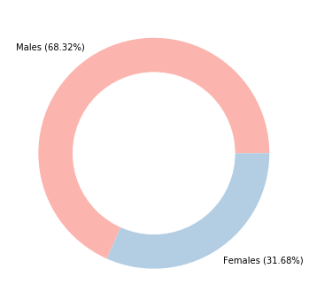

```python
from palettable.colorbrewer.qualitative import Pastel1_7

females = (df['sex']==0).sum()/df['sex'].count()
males = (df['sex']==1).sum()/df['sex'].count()
size = [males,females]
plt.figure(figsize=(10, 6))

my_circle = plt.Circle((0,0),0.7,color='white')
plt.pie(size, labels=['Males (68.32%)','Females (31.68%)'], colors=Pastel1_7.hex_colors)
p=plt.gcf()
p.gca().add_artist(my_circle)
plt.show()
```

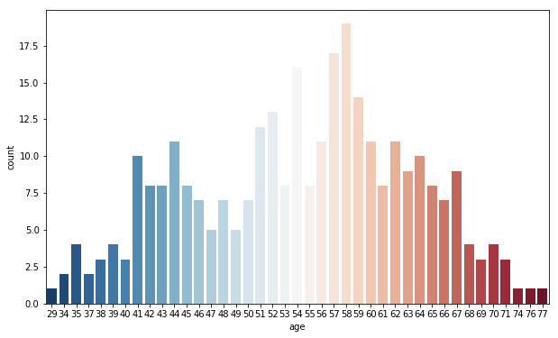

```python
plt.figure(figsize=(10, 6))
sns.countplot(x='age',data=df,palette='RdBu_r')
```

Above we have a pie chart of the gender distribution and the age distribution for the entire dataset. Overall we can see that there are more males than females and there are more older people than younger. Lets take a look at these in conjunction with one another.

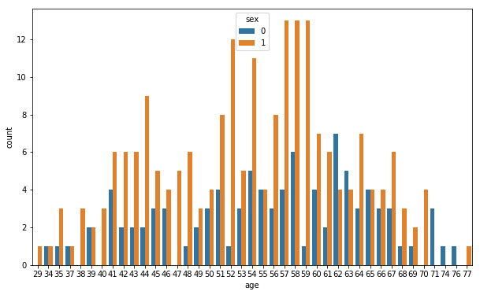

```python
plt.figure(figsize=(10, 6))
sns.countplot(x="age",hue="sex",data=df)
```

Looking at the above chart, we can see that there are mostly more males than females for each age value in the dataset, excluding a few. This makes us wonder- which gender and which age show more heart disease? Let's see.

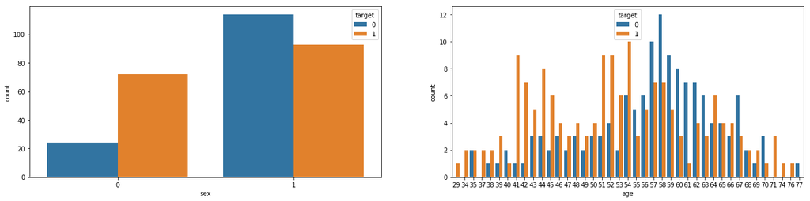

```python
f, axes = plt.subplots(1,2,figsize=(22, 5))
sns.countplot(x="sex",hue="target",data=df,ax=axes[0],)
sns.countplot(x="age",hue="target",data=df,ax=axes[1])
```

Let's also look at some of the other variables and their distributions in this dataset:

**Appendix I**

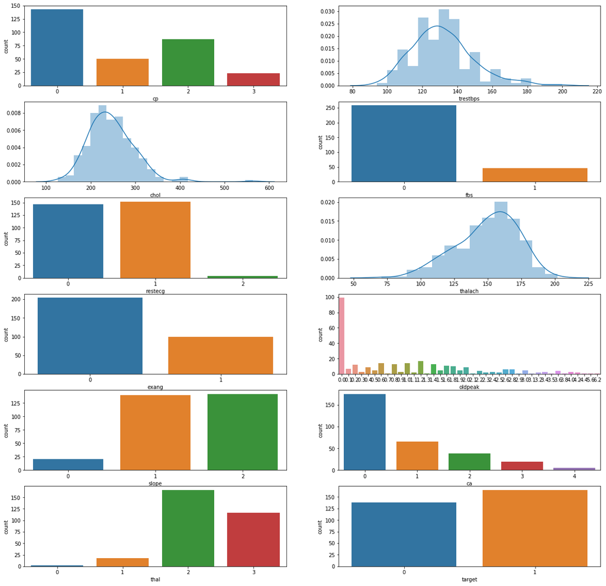

```python
f, axes = plt.subplots(6,2,figsize=(20, 20))
sns.countplot(x="cp",data=df,ax=axes[0,0],)
sns.distplot(df["trestbps"],ax=axes[0,1])
sns.distplot(df["chol"],ax=axes[1,0])
sns.countplot(x="fbs",data=df,ax=axes[1,1])
sns.countplot(x="restecg",data=df,ax=axes[2,0])
sns.distplot(df["thalach"],ax=axes[2,1])
sns.countplot(x="exang",data=df,ax=axes[3,0])
sns.countplot(x="oldpeak",data=df,ax=axes[3,1])
sns.countplot(x="slope",data=df,ax=axes[4,0])
sns.countplot(x="ca",data=df,ax=axes[4,1])
sns.countplot(x="thal",data=df,ax=axes[5,0])
sns.countplot(x="target",data=df,ax=axes[5,1])
```

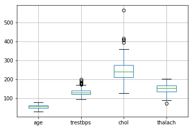

```python
plt.show(df.boxplot(column=["age","trestbps","chol",'thalach']))
```

There are also values as such in this boxplot, which may show outliers. Looking at cholesterol, we may have an outlier though it is not necessary to immediately remove it from the data. Outliers can tell the biggest story about a data point. Let's look at the data surrounding that point:

```python
df.loc[df['chol'] == df['chol'].max()]
```

|  | age | sex | cp | trestbps | chol | fbs | restecg | thalach | exang | oldpeak | slope | ca | thal | target |
| --- | --- | --- | --- | --- | --- | --- | --- | --- | --- | --- | --- | --- | --- | --- |
| 85 | 67 | 0 | 2 | 115 | 564 | 0 | 0 | 160 | 0 | 1.6 | 1 | 0 | 3 | 1 |

Here we have the outlier point in cholesterol, and no surprise that it has a 1 in the target column, meaning that this person got disease. We can look at this another way to possibly suggest that people with higher cholesterol may have a higher chance at a heart disease. Let's look at cholesterol and heart disease and see how their relationship is:

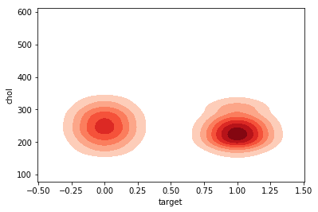

```python
sns.kdeplot(df['target'],df['chol'],cmap="Reds", shade=True, shade_lowest=False)
```

Although the outlier we found showed that a patient with high cholesterol had heart disease, it seems that according to the data and the plot above, most people with similar amounts of cholesterol were in the same ranges for heart disease. Let's look at some correlation values to see how each variable comes up against each other:

**Appendix II**

```python
df.corr()
```

|  | age | sex | cp | trestbps | chol | fbs | restecg | thalach | exang | oldpeak | slope | ca | thal | target |
| --- | --- | --- | --- | --- | --- | --- | --- | --- | --- | --- | --- | --- | --- | --- |
| age | 1.000000 | -0.098447 | -0.068653 | 0.279351 | 0.213678 | 0.121308 | -0.116211 | -0.398522 | 0.096801 | 0.210013 | -0.168814 | 0.276326 | 0.068001 | -0.225439 |
| sex | -0.098447 | 1.000000 | -0.049353 | -0.056769 | -0.197912 | 0.045032 | -0.058196 | -0.044020 | 0.141664 | 0.096093 | -0.030711 | 0.118261 | 0.210041 | -0.280937 |
| cp | -0.068653 | -0.049353 | 1.000000 | 0.047608 | -0.076904 | 0.094444 | 0.044421 | 0.295762 | -0.394280 | -0.149230 | 0.119717 | -0.181053 | -0.161736 | 0.433798 |
| trestbps | 0.279351 | -0.056769 | 0.047608 | 1.000000 | 0.123174 | 0.177531 | -0.114103 | -0.046698 | 0.067616 | 0.193216 | -0.121475 | 0.101389 | 0.062210 | -0.144931 |
| chol | 0.213678 | -0.197912 | -0.076904 | 0.123174 | 1.000000 | 0.013294 | -0.151040 | -0.009940 | 0.067023 | 0.053952 | -0.004038 | 0.070511 | 0.098803 | -0.085239 |
| fbs | 0.121308 | 0.045032 | 0.094444 | 0.177531 | 0.013294 | 1.000000 | -0.084189 | -0.008567 | 0.025665 | 0.005747 | -0.059894 | 0.137979 | -0.032019 | -0.028046 |
| restecg | -0.116211 | -0.058196 | 0.044421 | -0.114103 | -0.151040 | -0.084189 | 1.000000 | 0.044123 | -0.070733 | -0.058770 | 0.093045 | -0.072042 | -0.011981 | 0.137230 |
| thalach | -0.398522 | -0.044020 | 0.295762 | -0.046698 | -0.009940 | -0.008567 | 0.044123 | 1.000000 | -0.378812 | -0.344187 | 0.386784 | -0.213177 | -0.096439 | 0.421741 |
| exang | 0.096801 | 0.141664 | -0.394280 | 0.067616 | 0.067023 | 0.025665 | -0.070733 | -0.378812 | 1.000000 | 0.288223 | -0.257748 | 0.115739 | 0.206754 | -0.436757 |
| oldpeak | 0.210013 | 0.096093 | -0.149230 | 0.193216 | 0.053952 | 0.005747 | -0.058770 | -0.344187 | 0.288223 | 1.000000 | -0.577537 | 0.222682 | 0.210244 | -0.430696 |
| slope | -0.168814 | -0.030711 | 0.119717 | -0.121475 | -0.004038 | -0.059894 | 0.093045 | 0.386784 | -0.257748 | -0.577537 | 1.000000 | -0.080155 | -0.104764 | 0.345877 |
| ca | 0.276326 | 0.118261 | -0.181053 | 0.101389 | 0.070511 | 0.137979 | -0.072042 | -0.213177 | 0.115739 | 0.222682 | -0.080155 | 1.000000 | 0.151832 | -0.391724 |
| thal | 0.068001 | 0.210041 | -0.161736 | 0.062210 | 0.098803 | -0.032019 | -0.011981 | -0.096439 | 0.206754 | 0.210244 | -0.104764 | 0.151832 | 1.000000 | -0.344029 |
| target | -0.225439 | -0.280937 | 0.433798 | -0.144931 | -0.085239 | -0.028046 | 0.137230 | 0.421741 | -0.436757 | -0.430696 | 0.345877 | -0.391724 | -0.344029 | 1.000000 |

We can see that some of the strongest correlated values with heart disease (target) are 'cp' (chest pain) and 'thalach' (maximum heart rate achieved). Let's move onto some data mining.

## Data mining

Since our objective is to build a classifier for predicting/classifying whether or not a patient will have heart disease, we will use a Decision Tree Classifier to accomplish this. Since we are using the Decision Tree Classifier we do not necessarily have to scale these features. However, let's change some of our categorical variables.

```python
df2 = pd.get_dummies(data=df,columns=['cp','restecg','slope','ca','thal'],drop_first=True)
```

```python
df2.head()
```

|  | age | sex | trestbps | chol | fbs | thalach | exang | oldpeak | target | cp_1 | cp_2 | cp_3 | restecg_1 | restecg_2 | slope_1 | slope_2 | ca_1 | ca_2 | ca_3 | ca_4 | thal_1 | thal_2 | thal_3 |
| --- | --- | --- | --- | --- | --- | --- | --- | --- | --- | --- | --- | --- | --- | --- | --- | --- | --- | --- | --- | --- | --- | --- | --- |
| 0 | 63 | 1 | 145 | 233 | 1 | 150 | 0 | 2.3 | 1 | 0 | 0 | 1 | 0 | 0 | 0 | 0 | 0 | 0 | 0 | 0 | 1 | 0 | 0 |
| 1 | 37 | 1 | 130 | 250 | 0 | 187 | 0 | 3.5 | 1 | 0 | 1 | 0 | 1 | 0 | 0 | 0 | 0 | 0 | 0 | 0 | 0 | 1 | 0 |
| 2 | 41 | 0 | 130 | 204 | 0 | 172 | 0 | 1.4 | 1 | 1 | 0 | 0 | 0 | 0 | 0 | 1 | 0 | 0 | 0 | 0 | 0 | 1 | 0 |
| 3 | 56 | 1 | 120 | 236 | 0 | 178 | 0 | 0.8 | 1 | 1 | 0 | 0 | 1 | 0 | 0 | 1 | 0 | 0 | 0 | 0 | 0 | 1 | 0 |
| 4 | 57 | 0 | 120 | 354 | 0 | 163 | 1 | 0.6 | 1 | 0 | 0 | 0 | 1 | 0 | 0 | 1 | 0 | 0 | 0 | 0 | 0 | 1 | 0 |

We can see that the dummies function above did in fact make our categorical variables easier to work with. Now let's separate the target attribute and create a training and testing set for validation.

```python
X = df2.drop("target",axis=1)
```

```python
y = df2['target']
```

```python
from sklearn.model_selection import train_test_split
```

```python
X_train, X_test, y_train, y_test = train_test_split(X, y, test_size=0.3, random_state=42)
```

Now that we've changed the data into training and testing sets, lets start the Decision Tree.

### Decision Tree Classifier

```python
from sklearn.tree import DecisionTreeClassifier
```

```python
dtree = DecisionTreeClassifier()
```

```python
dtree.fit(X_train,y_train)
```

```
DecisionTreeClassifier(class_weight=None, criterion='gini', max_depth=None,
            max_features=None, max_leaf_nodes=None,
            min_impurity_decrease=0.0, min_impurity_split=None,
            min_samples_leaf=1, min_samples_split=2,
            min_weight_fraction_leaf=0.0, presort=False, random_state=None,
            splitter='best')
```

```python
predictions = dtree.predict(X_test)
```

```python
from sklearn.metrics import classification_report,confusion_matrix
```

```python
print(confusion_matrix(y_test,predictions))
print()
print(classification_report(y_test,predictions))
```

```
[[31 10]
 [20 30]]

              precision    recall  f1-score   support

           0       0.61      0.76      0.67        41
           1       0.75      0.60      0.67        50

   micro avg       0.67      0.67      0.67        91
   macro avg       0.68      0.68      0.67        91
weighted avg       0.69      0.67      0.67        91
```

So the model basically does close to around 67-69% accuracy. Let's check if the model is overfitting:

```python
dtree.score(X_train,y_train)
```

```
1.0
```

```python
dtree.score(X_test,y_test)
```

```
0.6703296703296703
```

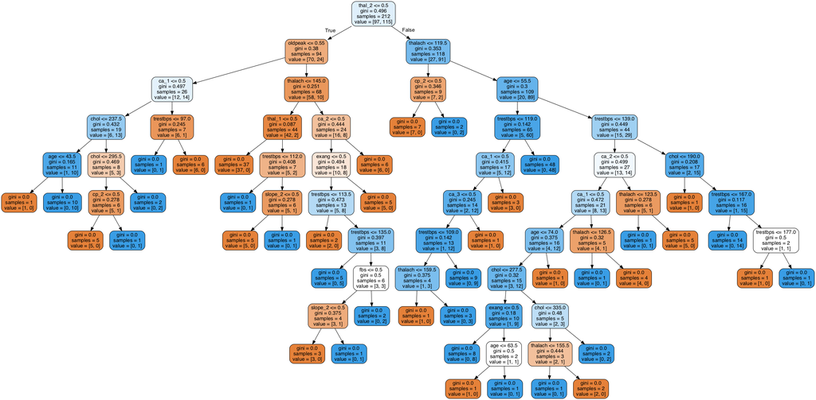

```python
from IPython.display import Image
from sklearn.externals.six import StringIO
from sklearn.tree import export_graphviz
import pydot

features = ['age', 'sex', 'trestbps', 'chol', 'fbs', 'thalach', 'exang', 'oldpeak', 'cp_1', 'cp_2', 'cp_3', 'restecg_1', 'restecg_2', 'slope_1', 'slope_2', 'ca_1', 'ca_2', 'ca_3', 'ca_4', 'thal_1', 'thal_2', 'thal_3']

dot_data = StringIO()
export_graphviz(dtree,out_file=dot_data,feature_names=features,filled=True,rounded=True)

graph = pydot.graph_from_dot_data(dot_data.getvalue())
Image(graph[0].create_png())
```

#### Introducing Grid Search For Optimizing Parameters

Looking at our accuracy for the training set, we can definitely see that the model overfit. Lets try using gridsearch to find the best parameters for the model:

```python
from sklearn.model_selection import GridSearchCV

parameters = [{
    'criterion' : ['entropy'],
    'min_samples_split': np.linspace(2,40,40,dtype=int)}]

dtree2 = DecisionTreeClassifier()
gs = GridSearchCV(dtree2,parameters,verbose=1, cv=5)
%time _ = gs.fit(X_train, y_train)
```

```
Fitting 5 folds for each of 40 candidates, totalling 200 fits
```

```
[Parallel(n_jobs=1)]: Using backend SequentialBackend with 1 concurrent workers.
```

```
CPU times: user 876 ms, sys: 6.47 ms, total: 882 ms
Wall time: 880 ms
```

```
[Parallel(n_jobs=1)]: Done 200 out of 200 | elapsed:    0.9s finished
```

```python
gs.best_params_, gs.best_score_
```

```
({'criterion': 'entropy', 'min_samples_split': 4}, 0.7405660377358491)
```

```python
dtree2 = DecisionTreeClassifier(criterion='entropy',min_samples_split=4)
dtree2.fit(X_train,y_train)
```

```
DecisionTreeClassifier(class_weight=None, criterion='entropy', max_depth=None,
            max_features=None, max_leaf_nodes=None,
            min_impurity_decrease=0.0, min_impurity_split=None,
            min_samples_leaf=1, min_samples_split=4,
            min_weight_fraction_leaf=0.0, presort=False, random_state=None,
            splitter='best')
```

```python
predictions = dtree2.predict(X_test)
```

```python
print(confusion_matrix(y_test,predictions))
print()
print(classification_report(y_test,predictions))
```

```
[[33  8]
 [17 33]]

              precision    recall  f1-score   support

           0       0.66      0.80      0.73        41
           1       0.80      0.66      0.73        50

   micro avg       0.73      0.73      0.73        91
   macro avg       0.73      0.73      0.73        91
weighted avg       0.74      0.73      0.73        91
```

```python
dtree2.score(X_train,y_train)
```

```
0.9858490566037735
```

```python
dtree2.score(X_test,y_test)
```

```
0.7252747252747253
```

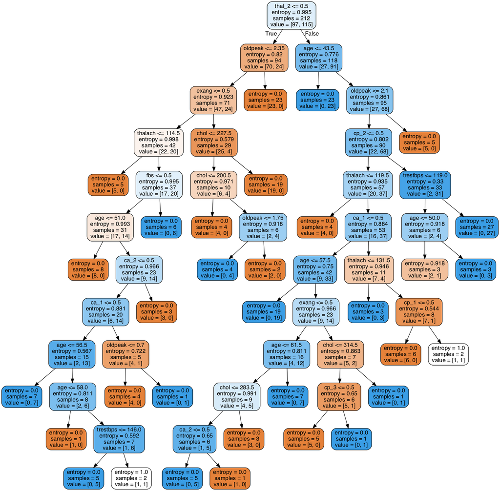

```python
dot_data = StringIO()
export_graphviz(dtree2,out_file=dot_data,feature_names=features,filled=True,rounded=True)

graph = pydot.graph_from_dot_data(dot_data.getvalue())
Image(graph[0].create_png())
```

We managed to bring up our accuracy a bit and slighly reduce overfitting. Not only that, we also managed to decrease the number of false negatives, which is very important in this kind of analysis. We would not want to tell our patient that he/she most likely does *not* have heart disease, only to find out that he/she does– that could be fatal.

### PCA

Now let's try and use PCA to see if we can reduce the dimensionality while keeping as much accuracy as we can. First let's scale the data for PCA usage.

```python
from sklearn.preprocessing import MinMaxScaler

scaler = MinMaxScaler()
```

```python
scaler.fit(X)
```

```
MinMaxScaler(copy=True, feature_range=(0, 1))
```

```python
scaled_data = scaler.transform(X)
```

Now let's actually start using PCA:

```python
from sklearn.decomposition import PCA
```

```python
pca = PCA(n_components=2)
```

```python
pca.fit(X)
```

```
PCA(copy=True, iterated_power='auto', n_components=2, random_state=None,
  svd_solver='auto', tol=0.0, whiten=False)
```

```python
x_pca = pca.transform(scaled_data)
```

```python
scaled_data.shape
```

```
(303, 22)
```

```python
x_pca.shape
```

```
(303, 2)
```

We've managed to reduce from 22 dimensions all the way to 2! Let's visualize these:

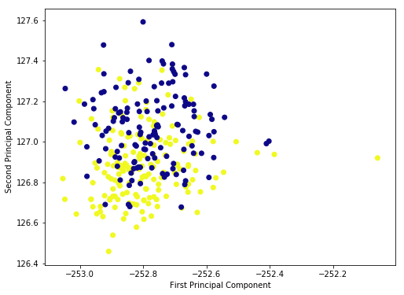

```python
plt.figure(figsize=(8,6))
plt.scatter(x_pca[:,0],x_pca[:,1],c=y,cmap="plasma")
plt.xlabel('First Principal Component')
plt.ylabel('Second Principal Component')
```

It's a bit hard to see the separation between the 'heart disease' and 'no heart disease', but lets try making this 3 components as well:

```python
pca3 = PCA(n_components=3)
```

```python
pca3.fit(X)
```

```
PCA(copy=True, iterated_power='auto', n_components=3, random_state=None,
  svd_solver='auto', tol=0.0, whiten=False)
```

```python
x3_pca = pca3.transform(scaled_data)
```

```python
scaled_data.shape
```

```
(303, 22)
```

```python
x3_pca.shape
```

```
(303, 3)
```

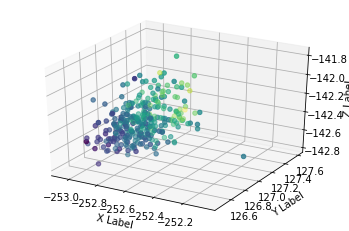

```python
from mpl_toolkits.mplot3d import Axes3D

fig = plt.figure()
ax = fig.add_subplot(111, projection='3d')

x = x3_pca[:,0]
y = x3_pca[:,1]
z = x3_pca[:,2]



ax.scatter(x, y, z, c=y, marker='o')

ax.set_xlabel('X Label')
ax.set_ylabel('Y Label')
ax.set_zlabel('Z Label')

plt.show()
```

### Decision Tree + PCA (n=2)

...and see how both PCA verions fair with the decision tree:

```python
X_train, X_test, y_train, y_test = train_test_split(x_pca, y, test_size=0.3, random_state=42)
```

```python
dtree3 = DecisionTreeClassifier(criterion='entropy', min_samples_split=22)
```

```python
dtree3.fit(X_train,y_train)
```

```
DecisionTreeClassifier(class_weight=None, criterion='entropy', max_depth=None,
            max_features=None, max_leaf_nodes=None,
            min_impurity_decrease=0.0, min_impurity_split=None,
            min_samples_leaf=1, min_samples_split=22,
            min_weight_fraction_leaf=0.0, presort=False, random_state=None,
            splitter='best')
```

```python
predictions = dtree3.predict(X_test)
```

```python
print(confusion_matrix(y_test,predictions))
print()
print(classification_report(y_test,predictions))
```

```
[[29 12]
 [18 32]]

              precision    recall  f1-score   support

           0       0.62      0.71      0.66        41
           1       0.73      0.64      0.68        50

   micro avg       0.67      0.67      0.67        91
   macro avg       0.67      0.67      0.67        91
weighted avg       0.68      0.67      0.67        91
```

```python
dtree3.score(X_train,y_train)
```

```
0.8679245283018868
```

```python
dtree3.score(X_test,y_test)
```

```
0.6703296703296703
```

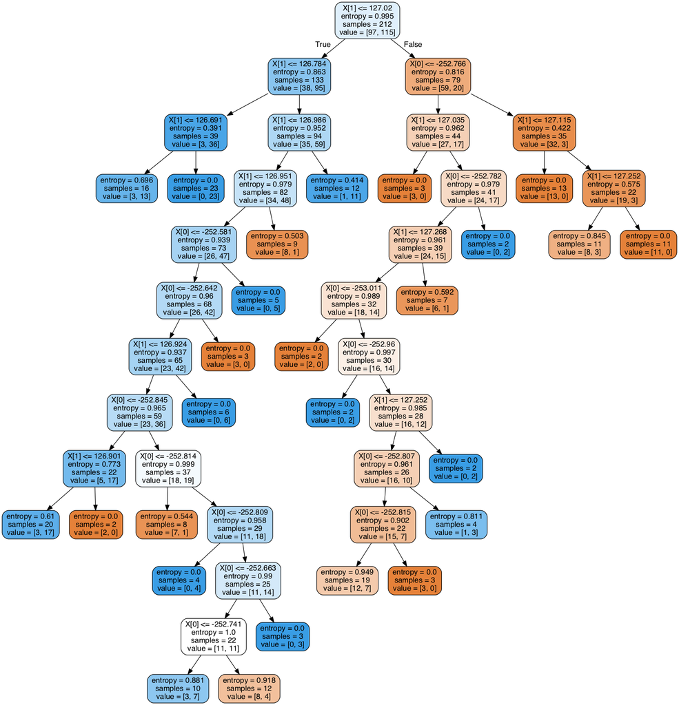

```python
dot_data = StringIO()
export_graphviz(dtree3,out_file=dot_data,filled=True,rounded=True)

graph = pydot.graph_from_dot_data(dot_data.getvalue())
Image(graph[0].create_png())
```

### Decision Tree + PCA (n=3)

```python
X_train, X_test, y_train, y_test = train_test_split(x3_pca, y, test_size=0.3, random_state=42)
```

```python
dtree4 = DecisionTreeClassifier(criterion='entropy', min_samples_split=22)
```

```python
dtree4.fit(X_train,y_train)
```

```
DecisionTreeClassifier(class_weight=None, criterion='entropy', max_depth=None,
            max_features=None, max_leaf_nodes=None,
            min_impurity_decrease=0.0, min_impurity_split=None,
            min_samples_leaf=1, min_samples_split=22,
            min_weight_fraction_leaf=0.0, presort=False, random_state=None,
            splitter='best')
```

```python
predictions = dtree4.predict(X_test)
```

```python
print(confusion_matrix(y_test,predictions))
print()
print(classification_report(y_test,predictions))
```

```
[[29 12]
 [15 35]]

              precision    recall  f1-score   support

           0       0.66      0.71      0.68        41
           1       0.74      0.70      0.72        50

   micro avg       0.70      0.70      0.70        91
   macro avg       0.70      0.70      0.70        91
weighted avg       0.71      0.70      0.70        91
```

```python
dtree4.score(X_train,y_train)
```

```
0.8207547169811321
```

```python
dtree4.score(X_test,y_test)
```

```
0.7032967032967034
```

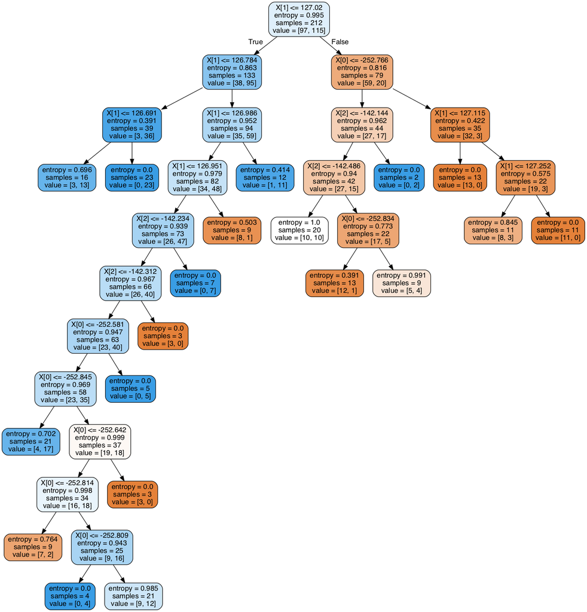

```python
dot_data = StringIO()
export_graphviz(dtree4,out_file=dot_data,filled=True,rounded=True)

graph = pydot.graph_from_dot_data(dot_data.getvalue())
Image(graph[0].create_png())
```

So in results it seems that we lost around 5% of information when reducing dimensions from 22 to 2/3. The PCA with n_components of 3 seem to have done better than it did with n_components = 2, but that's to be expected since we're dealing with information loss through compression. Let's try the ensemble technique "Random Forest Decision Classifier" and see if we can improve the model.

### Random Forest Decision Classifier

```python
X_train, X_test, y_train, y_test = train_test_split(X, y, test_size=0.3, random_state=42)
```

```python
from sklearn.ensemble import RandomForestClassifier

parameters = [{
    'n_estimators' : [200],
    'min_samples_split': np.linspace(2,40,40,dtype=int)}]
```

```python
rfc = RandomForestClassifier()
gs = GridSearchCV(rfc,parameters,verbose=1, cv=5)
%time _ = gs.fit(X_train, y_train)
```

```
Fitting 5 folds for each of 40 candidates, totalling 200 fits
```

```
[Parallel(n_jobs=1)]: Using backend SequentialBackend with 1 concurrent workers.
```

```
CPU times: user 26.4 s, sys: 18.5 ms, total: 26.5 s
Wall time: 26.5 s
```

```
[Parallel(n_jobs=1)]: Done 200 out of 200 | elapsed:   26.4s finished
```

```python
gs.best_params_, gs.best_score_
```

```
({'min_samples_split': 33, 'n_estimators': 200}, 0.8254716981132075)
```

```python
rfc = RandomForestClassifier(n_estimators=200,min_samples_split=33)
rfc.fit(X_train,y_train)
```

```
RandomForestClassifier(bootstrap=True, class_weight=None, criterion='gini',
            max_depth=None, max_features='auto', max_leaf_nodes=None,
            min_impurity_decrease=0.0, min_impurity_split=None,
            min_samples_leaf=1, min_samples_split=33,
            min_weight_fraction_leaf=0.0, n_estimators=200, n_jobs=None,
            oob_score=False, random_state=None, verbose=0,
            warm_start=False)
```

```python
predictions = rfc.predict(X_test)
```

```python
print(confusion_matrix(y_test,predictions))
print()
print(classification_report(y_test,predictions))
```

```
[[34  7]
 [ 9 41]]

              precision    recall  f1-score   support

           0       0.79      0.83      0.81        41
           1       0.85      0.82      0.84        50

   micro avg       0.82      0.82      0.82        91
   macro avg       0.82      0.82      0.82        91
weighted avg       0.83      0.82      0.82        91
```

```python
rfc.score(X_train,y_train)
```

```
0.8537735849056604
```

```python
rfc.score(X_test,y_test)
```

```
0.8241758241758241
```

After trying different parameters, we can see that we have better results with the Random Forest Classifier. All in all, although there are more parameters we could explore, there is an endless amount of fine tuning that goes into making sure a model is completely ready, and I feel that without more data or other techniques the current ceiling for accuracy is approximately 80-85%.